# developed_code

## Imports and set up connection to read from Google Drive

```python
import numpy as np
import pandas as pd
from datetime import datetime
from google.colab import drive
import copy
import random
import matplotlib.pyplot as plt
import seaborn as sns
from itertools import product

from sklearn.metrics import accuracy_score, classification_report, confusion_matrix, roc_auc_score
from sklearn.model_selection import train_test_split, GridSearchCV, ParameterGrid
from sklearn.ensemble import RandomForestClassifier

drive.mount('/content/drive')
```

## Load data files and combine main data

```python
df1 = pd.read_csv('/content/drive/MyDrive/PM_Appointments_2018.csv')
df2 = pd.read_csv('/content/drive/MyDrive/PM_Appointments_2019.csv')
df3 = pd.read_csv('/content/drive/MyDrive/PM_Appointments_2020.csv')
main_df = pd.concat([df1, df2, df3]) # concatenate main data
```

# Feature selection - main data

```python
columns_used = [
    'VEHICLE_NBR',
    'CUST_ACCOUNT_NBR',
    'APPOINTMENT_DT',
    'UNIT_CHECKIN_DT',
    'APPOINTMENT_PRIORITY_ID',
    'APPOINTMENT_TYPE_ID',
    'ISSUING_REG_DESC',
    'INDUSTRY_GROUP',
    'PM_TYPE',
    'RIDE_VEHICLE_TYPE_DESC'
]

main_df_filtered = copy.deepcopy(main_df[columns_used])
```

# Drops rows that contain missing values for

1. UNIT_CHECKIN_DT
2. APPOINTMENT_PRIORITY_ID
3. PM_TYPE

```python
main_df_filtered.dropna(subset=['UNIT_CHECKIN_DT', 'APPOINTMENT_PRIORITY_ID', 'PM_TYPE'], inplace=True)
```

# Convert datetime format and create time difference

```python
main_df_filtered['APPOINTMENT_DT'] = pd.to_datetime(main_df_filtered['APPOINTMENT_DT'])
main_df_filtered['UNIT_CHECKIN_DT'] = pd.to_datetime(main_df_filtered['UNIT_CHECKIN_DT'])
main_df_filtered['TIME_DIFF_APP_UC'] = abs((main_df_filtered['UNIT_CHECKIN_DT'] - main_df_filtered['APPOINTMENT_DT']).dt.total_seconds() / 3600)
```

# Feature engineering

## Type conversions

```python
# Convert the following columns to string type:
# APPOINTMENT_PRIORITY_ID
# APPOINTMENT_TYPE_ID
main_df_filtered['APPOINTMENT_PRIORITY_ID'] = main_df_filtered['APPOINTMENT_PRIORITY_ID'].astype(int).astype(str)
main_df_filtered['APPOINTMENT_TYPE_ID'] = main_df_filtered['APPOINTMENT_TYPE_ID'].astype(int).astype(str)
```

## Create additional datetime features

- Weekday
- Time slot of the day

```python
# Method to create dummy variables for seasonal features
def convert_to_date_binary(df, datetime_column, week_day):
    #Convert the datetime column to datetime format
    df[datetime_column] = pd.to_datetime(df[datetime_column])

    #Extract weekdays
    df[week_day] = df[datetime_column].dt.weekday.astype(int).astype(str)

     #Add binary columns for time of day with the desired naming convention
    df[datetime_column + '_Morning'] = ((df[datetime_column].dt.hour >= 6) & (df[datetime_column].dt.hour < 12)).astype(int)
    df[datetime_column + '_Afternoon'] = ((df[datetime_column].dt.hour >= 12) & (df[datetime_column].dt.hour < 18)).astype(int)
    df[datetime_column + '_Night'] = ((df[datetime_column].dt.hour >= 18) | (df[datetime_column].dt.hour < 6)).astype(int)

    return df
```

```python
main_df_filtered = convert_to_date_binary(main_df_filtered, 'APPOINTMENT_DT', 'APPOINTMENT_WEEKDAY')
main_df_filtered = convert_to_date_binary(main_df_filtered, 'UNIT_CHECKIN_DT', 'UNIT_CHECKIN_WEEKDAY')
```

## One hot encoding

```python
main_df_filtered = pd.get_dummies(main_df_filtered)
```

```python
pd.set_option('display.max_columns', None)
main_df_filtered.head()
```

|  | VEHICLE_NBR | CUST_ACCOUNT_NBR | APPOINTMENT_DT | UNIT_CHECKIN_DT | TIME_DIFF_APP_UC | APPOINTMENT_DT_Morning | APPOINTMENT_DT_Afternoon | APPOINTMENT_DT_Night | UNIT_CHECKIN_DT_Morning | UNIT_CHECKIN_DT_Afternoon | UNIT_CHECKIN_DT_Night | APPOINTMENT_PRIORITY_ID_1 | APPOINTMENT_PRIORITY_ID_10 | APPOINTMENT_PRIORITY_ID_2 | APPOINTMENT_PRIORITY_ID_3 | APPOINTMENT_PRIORITY_ID_4 | APPOINTMENT_PRIORITY_ID_5 | APPOINTMENT_PRIORITY_ID_6 | APPOINTMENT_PRIORITY_ID_7 | APPOINTMENT_PRIORITY_ID_8 | APPOINTMENT_TYPE_ID_1 | APPOINTMENT_TYPE_ID_2 | ISSUING_REG_DESC_CANADA REGION | ISSUING_REG_DESC_OPS-CENTRAL REGION | ISSUING_REG_DESC_OPS-EAST REGION | ISSUING_REG_DESC_OPS-NORTH REGION | ISSUING_REG_DESC_OPS-NORTHEAST REGION | ISSUING_REG_DESC_OPS-SOUTH REGION | ISSUING_REG_DESC_OPS-SOUTHEAST REGION | … |
| --- | --- | --- | --- | --- | --- | --- | --- | --- | --- | --- | --- | --- | --- | --- | --- | --- | --- | --- | --- | --- | --- | --- | --- | --- | --- | --- | --- | --- | --- | --- |
| 0 | 659811 | 4605 | 2018-10-03 02:33:53.013000+00:00 | 2018-10-03 02:33:53.013000+00:00 | 0.000000 | 0 | 0 | 1 | 0 | 0 | 1 | 0 | 0 | 0 | 0 | 0 | 0 | 1 | 0 | 0 | 0 | 1 | 0 | 0 | 1 | 0 | 0 | 0 | 0 | … |
| 1 | 655428 | 90662 | 2018-01-05 16:30:00+00:00 | 2017-12-28 11:13:15.260000+00:00 | 197.279094 | 0 | 1 | 0 | 1 | 0 | 0 | 0 | 0 | 0 | 0 | 0 | 1 | 0 | 0 | 0 | 1 | 0 | 0 | 0 | 0 | 0 | 0 | 0 | 1 | … |
| 2 | 678623 | 54816 | 2018-06-29 14:58:36.893000+00:00 | 2018-06-29 14:58:36.893000+00:00 | 0.000000 | 0 | 1 | 0 | 0 | 1 | 0 | 0 | 0 | 0 | 0 | 0 | 0 | 1 | 0 | 0 | 0 | 1 | 1 | 0 | 0 | 0 | 0 | 0 | 0 | … |
| 3 | 657618 | 35818 | 2018-07-20 15:03:31.440000+00:00 | 2018-07-20 15:03:31.440000+00:00 | 0.000000 | 0 | 1 | 0 | 0 | 1 | 0 | 0 | 0 | 0 | 0 | 0 | 0 | 1 | 0 | 0 | 0 | 1 | 0 | 0 | 1 | 0 | 0 | 0 | 0 | … |
| 4 | 996735 | 67487 | 2018-11-12 00:44:47.313000+00:00 | 2018-11-12 00:44:47.313000+00:00 | 0.000000 | 0 | 0 | 1 | 0 | 0 | 1 | 0 | 1 | 0 | 0 | 0 | 0 | 0 | 0 | 0 | 0 | 1 | 0 | 0 | 1 | 0 | 0 | 0 | 0 | … |

## Labeling ground truth

- If appointment and checkin date, weekday, and period during the day are the same, assign 1 to SHOW_UP. Otherwise assign 0

```python
days = ['Monday', 'Tuesday', 'Wednesday', 'Thursday', 'Friday', 'Saturday', 'Sunday']
time_periods = ['_Morning', '_Afternoon', '_Night']

# Initialize the SHOW_UP column with 0
main_df_filtered['SHOW_UP'] = 0

same_week_rows = (main_df_filtered['APPOINTMENT_DT'].dt.isocalendar().week == main_df_filtered['UNIT_CHECKIN_DT'].dt.isocalendar().week).values

for day_num, day_name in enumerate(days):
    for period in time_periods:
        day_condition = (main_df_filtered[f'APPOINTMENT_WEEKDAY_{day_num}'] == 1) & (main_df_filtered[f'UNIT_CHECKIN_WEEKDAY_{day_num}'] == 1)
        appointment_time_condition = main_df_filtered[f'APPOINTMENT_DT{period}'] == 1
        checkin_time_condition = main_df_filtered[f'UNIT_CHECKIN_DT{period}'] == 1

        combined_condition = same_week_rows & day_condition & appointment_time_condition & checkin_time_condition
        main_df_filtered.loc[combined_condition, 'SHOW_UP'] = 1

main_df_filtered = main_df_filtered.reset_index(drop=True)
```

# Stratified sampling

- Our targeted number of overall sample is 100,000 observations.
- From the analysis below, we see that it's infeasible to perform stratified sampling if we create weekday-related or time-period related stratas, given that we must sample a balanced distribution of show-ups vs. no-shows in the first place. This is because we have a low number of observations on Saturdays and Sundays to begin with, in addition to a low number of observations at night.
- Two potential resolutions would be to:
  1. Set replace to true during sampling, but this simply duplicates the actual data. We do not want this.
  2. Reduce the number of overall samples. However, the number below suggests that the best we can do for this alternative would be to create (2 outcomes * 3 time periods) stratas, but even this leads to just 3,802 * 6 = 22,812 samples in total, which is too low compared to out targeted 100,000.
- Therefore, we only perform stratified sampling based on outcomes (show_up = 1 vs. 0).

## Pre-sampling analysis

```python
stratified_format = main_df_filtered[main_df_filtered['TIME_DIFF_APP_UC'] != 0].copy()

def get_time_of_day(row):
  if row['APPOINTMENT_DT_Morning'] == 1:
      return 'Morning'
  elif row['APPOINTMENT_DT_Afternoon'] == 1:
      return 'Afternoon'
  elif row['APPOINTMENT_DT_Night'] == 1:
      return 'Night'

def get_weekday(row):
  if row['APPOINTMENT_WEEKDAY_0'] == 1:
      return 'Monday'
  elif row['APPOINTMENT_WEEKDAY_1'] == 1:
      return 'Tuesday'
  elif row['APPOINTMENT_WEEKDAY_2'] == 1:
      return 'Wednesday'
  elif row['APPOINTMENT_WEEKDAY_3'] == 1:
      return 'Thursday'
  elif row['APPOINTMENT_WEEKDAY_4'] == 1:
      return 'Friday'
  elif row['APPOINTMENT_WEEKDAY_5'] == 1:
      return 'Saturday'
  elif row['APPOINTMENT_WEEKDAY_6'] == 1:
      return 'Sunday'

def get_outcome(row):
  if row['SHOW_UP'] == 1:
      return 'show_up'
  else:
      return 'no_show'

stratified_format['WEEKDAY'] = stratified_format.apply(get_weekday, axis=1)
stratified_format['TIME_OF_DAY'] = stratified_format.apply(get_time_of_day, axis=1)
stratified_format['OUTCOME'] = stratified_format.apply(get_outcome, axis=1)

stratified_format['STRAT_KEY_COMPLETE'] = stratified_format['WEEKDAY'] + '_' + stratified_format['TIME_OF_DAY'] + '_' + stratified_format['OUTCOME']
stratified_format['STRAT_KEY_WEEKDAY_OUTCOME'] = stratified_format['WEEKDAY'] + '_' + stratified_format['OUTCOME']
stratified_format['STRAT_KEY_TIME_OUTCOME'] = stratified_format['TIME_OF_DAY'] + '_' + stratified_format['OUTCOME']

s1 = stratified_format.groupby('STRAT_KEY_COMPLETE').size()
s2 = stratified_format.groupby('STRAT_KEY_WEEKDAY_OUTCOME').size()
s3 = stratified_format.groupby('STRAT_KEY_TIME_OUTCOME').size()
s4 = stratified_format.groupby('OUTCOME').size()

print('Distribution under 2 outcomes by 7 weekdays by 3 time periods')
print(s1)
print('\n')

print('Distribution under 2 outcomes by 7 weekdays')
print(s2)
print('\n')

print('Distribution under 2 outcomes by 3 time periods')
print(s3)
print('\n')

print('Distribution of outcomes')
print(s4)
```

```
Distribution under 2 outcomes by 7 weekdays by 3 time periods
STRAT_KEY_COMPLETE
Friday_Afternoon_no_show       16426
Friday_Afternoon_show_up        7235
Friday_Morning_no_show         15555
Friday_Morning_show_up          3522
Friday_Night_no_show           12142
Friday_Night_show_up             648
Monday_Afternoon_no_show        9894
Monday_Afternoon_show_up        4949
Monday_Morning_no_show         11887
Monday_Morning_show_up          3307
Monday_Night_no_show            6206
Monday_Night_show_up             635
Saturday_Afternoon_no_show      3734
Saturday_Afternoon_show_up       384
Saturday_Morning_no_show        8853
Saturday_Morning_show_up        4780
Saturday_Night_no_show          3135
Saturday_Night_show_up           105
Sunday_Afternoon_no_show        1380
Sunday_Afternoon_show_up         150
Sunday_Morning_no_show          2196
Sunday_Morning_show_up           342
Sunday_Night_no_show            1672
Sunday_Night_show_up              30
Thursday_Afternoon_no_show     15517
Thursday_Afternoon_show_up      6443
Thursday_Morning_no_show       15507
Thursday_Morning_show_up        3582
Thursday_Night_no_show         11057
Thursday_Night_show_up           713
Tuesday_Afternoon_no_show      12795
Tuesday_Afternoon_show_up       6957
Tuesday_Morning_no_show        13060
Tuesday_Morning_show_up         3998
Tuesday_Night_no_show           7975
Tuesday_Night_show_up            802
Wednesday_Afternoon_no_show    14423
Wednesday_Afternoon_show_up     6609
```

[output cut: 27 more lines]

```
STRAT_KEY_TIME_OUTCOME
Afternoon_no_show    74169
Afternoon_show_up    32727
Morning_no_show      81161
Morning_show_up      23538
Night_no_show        51351
Night_show_up         3802
dtype: int64


Distribution of outcomes
OUTCOME
no_show    206681
show_up     60067
dtype: int64
```

## Sample

```python
appointments = main_df_filtered[main_df_filtered['TIME_DIFF_APP_UC'] != 0]

show_ups = appointments[appointments['SHOW_UP'] == 1]
non_show_ups = appointments[appointments['SHOW_UP'] == 0]

show_ups = show_ups.sample(n = 50000, random_state = 123)
non_show_ups = non_show_ups.sample(n = 50000, random_state = 123)
sampled_df = pd.concat([show_ups, non_show_ups])
```

## Examine distribution after sampling

```python
stratified_format = sampled_df.copy()

def get_time_of_day(row):
  if row['APPOINTMENT_DT_Morning'] == 1:
      return 'Morning'
  elif row['APPOINTMENT_DT_Afternoon'] == 1:
      return 'Afternoon'
  elif row['APPOINTMENT_DT_Night'] == 1:
      return 'Night'

def get_weekday(row):
  if row['APPOINTMENT_WEEKDAY_0'] == 1:
      return 'Monday'
  elif row['APPOINTMENT_WEEKDAY_1'] == 1:
      return 'Tuesday'
  elif row['APPOINTMENT_WEEKDAY_2'] == 1:
      return 'Wednesday'
  elif row['APPOINTMENT_WEEKDAY_3'] == 1:
      return 'Thursday'
  elif row['APPOINTMENT_WEEKDAY_4'] == 1:
      return 'Friday'
  elif row['APPOINTMENT_WEEKDAY_5'] == 1:
      return 'Saturday'
  elif row['APPOINTMENT_WEEKDAY_6'] == 1:
      return 'Sunday'

def get_outcome(row):
  if row['SHOW_UP'] == 1:
      return 'show_up'
  else:
      return 'no_show'

stratified_format['WEEKDAY'] = stratified_format.apply(get_weekday, axis=1)
stratified_format['TIME_OF_DAY'] = stratified_format.apply(get_time_of_day, axis=1)
stratified_format['OUTCOME'] = stratified_format.apply(get_outcome, axis=1)

stratified_format['STRAT_KEY_COMPLETE'] = stratified_format['WEEKDAY'] + '_' + stratified_format['TIME_OF_DAY'] + '_' + stratified_format['OUTCOME']
stratified_format['STRAT_KEY_WEEKDAY_OUTCOME'] = stratified_format['WEEKDAY'] + '_' + stratified_format['OUTCOME']
stratified_format['STRAT_KEY_TIME_OUTCOME'] = stratified_format['TIME_OF_DAY'] + '_' + stratified_format['OUTCOME']

s1 = stratified_format.groupby('STRAT_KEY_COMPLETE').size()
s2 = stratified_format.groupby('STRAT_KEY_WEEKDAY_OUTCOME').size()
s3 = stratified_format.groupby('STRAT_KEY_TIME_OUTCOME').size()
s4 = stratified_format.groupby('OUTCOME').size()

print('Distribution under 2 outcomes by 7 weekdays by 3 time periods')
print(s1)
print('\n')

print('Distribution under 2 outcomes by 7 weekdays')
print(s2)
print('\n')

print('Distribution under 2 outcomes by 3 time periods')
print(s3)
print('\n')

print('Distribution of outcomes')
print(s4)
```

```
Distribution under 2 outcomes by 7 weekdays by 3 time periods
STRAT_KEY_COMPLETE
Friday_Afternoon_no_show       3925
Friday_Afternoon_show_up       6019
Friday_Morning_no_show         3766
Friday_Morning_show_up         2948
Friday_Night_no_show           2923
Friday_Night_show_up            539
Monday_Afternoon_no_show       2415
Monday_Afternoon_show_up       4140
Monday_Morning_no_show         2810
Monday_Morning_show_up         2760
Monday_Night_no_show           1516
Monday_Night_show_up            539
Saturday_Afternoon_no_show      944
Saturday_Afternoon_show_up      320
Saturday_Morning_no_show       2177
Saturday_Morning_show_up       3969
Saturday_Night_no_show          779
Saturday_Night_show_up           85
Sunday_Afternoon_no_show        363
Sunday_Afternoon_show_up        123
Sunday_Morning_no_show          517
Sunday_Morning_show_up          295
Sunday_Night_no_show            411
Sunday_Night_show_up             24
Thursday_Afternoon_no_show     3772
Thursday_Afternoon_show_up     5389
Thursday_Morning_no_show       3834
Thursday_Morning_show_up       2948
Thursday_Night_no_show         2639
Thursday_Night_show_up          598
Tuesday_Afternoon_no_show      3083
Tuesday_Afternoon_show_up      5791
Tuesday_Morning_no_show        3039
Tuesday_Morning_show_up        3322
Tuesday_Night_no_show          1960
Tuesday_Night_show_up           676
Wednesday_Afternoon_no_show    3508
Wednesday_Afternoon_show_up    5475
```

[output cut: 27 more lines]

```
STRAT_KEY_TIME_OUTCOME
Afternoon_no_show    18010
Afternoon_show_up    27257
Morning_no_show      19580
Morning_show_up      19568
Night_no_show        12410
Night_show_up         3175
dtype: int64


Distribution of outcomes
OUTCOME
no_show    50000
show_up    50000
dtype: int64
```

# Modeling - random forest

## Finalize input (x) and output (y)

```python
x = sampled_df.drop(columns=['VEHICLE_NBR', 'CUST_ACCOUNT_NBR', 'UNIT_CHECKIN_DT', 'APPOINTMENT_DT',
                             'UNIT_CHECKIN_DT_Morning', 'UNIT_CHECKIN_DT_Afternoon', 'UNIT_CHECKIN_DT_Night',
                             'UNIT_CHECKIN_WEEKDAY_0', 'UNIT_CHECKIN_WEEKDAY_1', 'UNIT_CHECKIN_WEEKDAY_2',
                             'UNIT_CHECKIN_WEEKDAY_3', 'UNIT_CHECKIN_WEEKDAY_4', 'UNIT_CHECKIN_WEEKDAY_5',
                             'UNIT_CHECKIN_WEEKDAY_6', 'TIME_DIFF_APP_UC', 'SHOW_UP'])
y = sampled_df['SHOW_UP']
```

```python
pd.set_option('display.max_columns', None)
x.head()
```

|  | APPOINTMENT_DT_Morning | APPOINTMENT_DT_Afternoon | APPOINTMENT_DT_Night | APPOINTMENT_PRIORITY_ID_1 | APPOINTMENT_PRIORITY_ID_10 | APPOINTMENT_PRIORITY_ID_2 | APPOINTMENT_PRIORITY_ID_3 | APPOINTMENT_PRIORITY_ID_4 | APPOINTMENT_PRIORITY_ID_5 | APPOINTMENT_PRIORITY_ID_6 | APPOINTMENT_PRIORITY_ID_7 | APPOINTMENT_PRIORITY_ID_8 | APPOINTMENT_TYPE_ID_1 | APPOINTMENT_TYPE_ID_2 | ISSUING_REG_DESC_CANADA REGION | ISSUING_REG_DESC_OPS-CENTRAL REGION | ISSUING_REG_DESC_OPS-EAST REGION | ISSUING_REG_DESC_OPS-NORTH REGION | ISSUING_REG_DESC_OPS-NORTHEAST REGION | ISSUING_REG_DESC_OPS-SOUTH REGION | ISSUING_REG_DESC_OPS-SOUTHEAST REGION | ISSUING_REG_DESC_OPS-WEST REGION | INDUSTRY_GROUP_All Other | INDUSTRY_GROUP_Automotive | INDUSTRY_GROUP_Business & Personal Services | INDUSTRY_GROUP_Food & Beverage | INDUSTRY_GROUP_Government & Utilities | INDUSTRY_GROUP_High Tech Mfg. & Distribution | INDUSTRY_GROUP_Housing | … |
| --- | --- | --- | --- | --- | --- | --- | --- | --- | --- | --- | --- | --- | --- | --- | --- | --- | --- | --- | --- | --- | --- | --- | --- | --- | --- | --- | --- | --- | --- | --- |
| 439424 | 0 | 1 | 0 | 0 | 0 | 0 | 0 | 0 | 0 | 1 | 0 | 0 | 1 | 0 | 1 | 0 | 0 | 0 | 0 | 0 | 0 | 0 | 0 | 0 | 0 | 0 | 0 | 0 | 0 | … |
| 295038 | 1 | 0 | 0 | 0 | 0 | 0 | 0 | 0 | 1 | 0 | 0 | 0 | 1 | 0 | 0 | 0 | 0 | 0 | 0 | 0 | 0 | 1 | 0 | 0 | 0 | 1 | 0 | 0 | 0 | … |
| 273075 | 0 | 1 | 0 | 0 | 0 | 0 | 0 | 0 | 1 | 0 | 0 | 0 | 1 | 0 | 0 | 1 | 0 | 0 | 0 | 0 | 0 | 0 | 0 | 1 | 0 | 0 | 0 | 0 | 0 | … |
| 402040 | 1 | 0 | 0 | 0 | 0 | 0 | 0 | 0 | 1 | 0 | 0 | 0 | 1 | 0 | 0 | 0 | 1 | 0 | 0 | 0 | 0 | 0 | 0 | 0 | 0 | 0 | 1 | 0 | 0 | … |
| 1211136 | 1 | 0 | 0 | 0 | 0 | 0 | 0 | 0 | 1 | 0 | 0 | 0 | 1 | 0 | 0 | 0 | 0 | 0 | 0 | 0 | 0 | 1 | 0 | 0 | 0 | 0 | 0 | 0 | 0 | … |

```python
x.shape
```

```
(100000, 74)
```

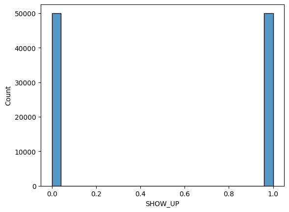

```python
sns.histplot(y)
```

## Hyperparameter tuning - Uncomment before running

```python
# # Reduce sample size to 5% of all data to improve runtime
# X_train, X_test, y_train, y_test = train_test_split(x, y, train_size=4000, test_size=1000, random_state=42)

# # Define parameter space
# param_space = {
#     'n_estimators': list(range(100, 2001, 100)),
#     'max_depth': [None] + list(range(10, 101, 5)),
#     'min_samples_split': list(range(2, 22, 5)),
#     'min_samples_leaf': [1, 2, 4]
# }

# # Number of iterations for random walk
# n_iterations = 200

# model = RandomForestClassifier(random_state=42)
# best_score = float('-inf')
# best_params = None
# best_model = None

# # Random walk over the parameter space
# random.seed(42)
# for _ in range(n_iterations):
#     params = {k: random.choice(v) for k, v in param_space.items()}
#     model.set_params(**params)
#     model.fit(X_train, y_train)

#     # Predict and calculate AUC
#     y_pred_prob = model.predict_proba(X_test)[:, 1]
#     auc = roc_auc_score(y_test, y_pred_prob)

#     if auc > best_score:
#         best_score = auc
#         best_params = params
#         best_model = model

# print(f"Best Parameters: {best_params}")
# print(f"AUC of the best model: {best_score:.4f}")
```

## Final model with tuned parameters

```
Classification Report for Training Data:
              precision    recall  f1-score   support

 Non Show-up       0.85      0.73      0.79     40035
     Show-Up       0.77      0.87      0.81     39965

    accuracy                           0.80     80000
   macro avg       0.81      0.80      0.80     80000
weighted avg       0.81      0.80      0.80     80000
```

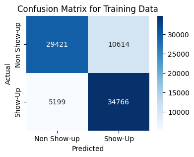

```
AUC Score for Training Data:
0.8829


====================================================
Classification Report for Test Data:
              precision    recall  f1-score   support

 Non Show-up       0.82      0.71      0.76      9965
     Show-Up       0.75      0.85      0.80     10035

    accuracy                           0.78     20000
   macro avg       0.79      0.78      0.78     20000
weighted avg       0.79      0.78      0.78     20000
```

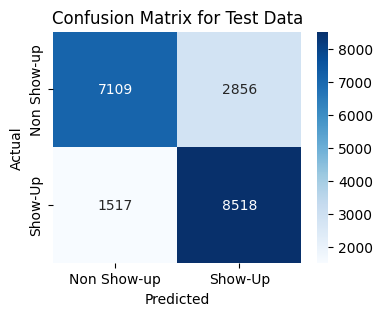

```
AUC Score for Test Data:
0.8503
```

```python
X_train, X_test, y_train, y_test = train_test_split(x, y, test_size=0.2, random_state=42)

model = RandomForestClassifier(n_estimators=400, max_depth=20, min_samples_split=12, random_state=42)
model.fit(X_train, y_train)

# Predict on training data
y_train_pred = model.predict(X_train)
y_train_pred_prob = model.predict_proba(X_train)[:, 1]

# Classification report
train_class_report = classification_report(y_train, y_train_pred, target_names=['Non Show-up', 'Show-Up'])
print("Classification Report for Training Data:")
print(train_class_report)

# Confusion Matrix
train_conf_matrix = confusion_matrix(y_train, y_train_pred)

# Plotting Confusion Matrix
plt.figure(figsize=(4, 3))
sns.heatmap(train_conf_matrix, annot=True, fmt="d", cmap='Blues', xticklabels=['Non Show-up', 'Show-Up'], yticklabels=['Non Show-up', 'Show-Up'])
plt.ylabel('Actual')
plt.xlabel('Predicted')
plt.title('Confusion Matrix for Training Data')
plt.show()

# AUC
train_auc_score = roc_auc_score(y_train, y_train_pred_prob)
print("\nAUC Score for Training Data:")
print(f"{train_auc_score:.4f}")

# Predict on test data
print('\n\n====================================================')
y_pred = model.predict(X_test)
y_pred_prob = model.predict_proba(X_test)[:, 1]

# Classification report
class_report = classification_report(y_test, y_pred, target_names=['Non Show-up', 'Show-Up'])
print("Classification Report for Test Data:")
print(class_report)

# Confusion Matrix
conf_matrix = confusion_matrix(y_test, y_pred)

# Plotting Confusion Matrix
plt.figure(figsize=(4, 3))
sns.heatmap(conf_matrix, annot=True, fmt="d", cmap='Blues', xticklabels=['Non Show-up', 'Show-Up'], yticklabels=['Non Show-up', 'Show-Up'])
plt.ylabel('Actual')
plt.xlabel('Predicted')
plt.title('Confusion Matrix for Test Data')
plt.show()

# AUC
auc_score = roc_auc_score(y_test, y_pred_prob)
print("\nAUC Score for Test Data:")
print(f"{auc_score:.4f}")
```

## Feature importance analysis

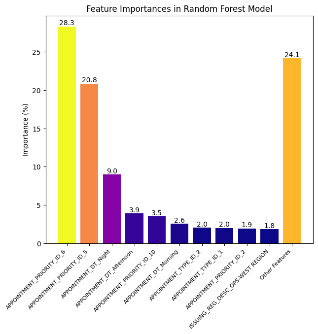

```python
feature_names = np.array(x.columns)
feature_importances = model.feature_importances_

# Convert importances to percentages
importances_sum = np.sum(feature_importances)
importances_percentage = 100 * (feature_importances / importances_sum)

# Sort features by importance and select top 10
indices = np.argsort(importances_percentage)[::-1]
top_indices = indices[:10]
top_features = feature_names[top_indices]
top_importances = importances_percentage[top_indices]

# Aggregate the remaining features
other_importance = np.sum(importances_percentage[indices[10:]])
final_features = np.concatenate((top_features, ["Other Features"]))
final_importances = np.concatenate((top_importances, [other_importance]))

# Normalize and set colors for plotting
cmap = plt.cm.plasma
norm = plt.Normalize(min(final_importances), max(final_importances))
colors = cmap(norm(final_importances))

# Plotting with gradient colors and adding labels
plt.figure(figsize=(7, 6))
bars = plt.bar(final_features, final_importances, color=colors)
plt.ylabel('Importance (%)')
plt.title('Feature Importances in Random Forest Model')
plt.xticks(rotation=45, ha='right', fontsize=8)

# Adding labels on top of each bar
for bar in bars:
    yval = bar.get_height()
    plt.text(bar.get_x() + bar.get_width()/2, yval, round(yval, 1), ha='center', va='bottom')

plt.show()
```

# Show-up rate prediction

## Predict probabliities for the total average show-up rate of 21 time slots of all appointments data

```python
# Attach probabilities to dataframe
all_data = appointments.drop(columns=['VEHICLE_NBR', 'CUST_ACCOUNT_NBR', 'UNIT_CHECKIN_DT', 'APPOINTMENT_DT',
                             'UNIT_CHECKIN_DT_Morning', 'UNIT_CHECKIN_DT_Afternoon', 'UNIT_CHECKIN_DT_Night',
                             'UNIT_CHECKIN_WEEKDAY_0', 'UNIT_CHECKIN_WEEKDAY_1', 'UNIT_CHECKIN_WEEKDAY_2',
                             'UNIT_CHECKIN_WEEKDAY_3', 'UNIT_CHECKIN_WEEKDAY_4', 'UNIT_CHECKIN_WEEKDAY_5',
                             'UNIT_CHECKIN_WEEKDAY_6', 'TIME_DIFF_APP_UC', 'SHOW_UP'])
all_data['show_up_prob'] = model.predict_proba(all_data)[:, 1]

# Extract time and weekday from one-hot encoding
all_data['appointment_day'] = all_data.filter(like='APPOINTMENT_WEEKDAY_').idxmax(axis=1).str[-1].astype(int)
all_data['appointment_time'] = all_data.filter(like='APPOINTMENT_DT_').idxmax(axis=1).str.split('_').str[-1]

# Group and average probabilities, then pivot
pivot_table = all_data.groupby(['appointment_day', 'appointment_time'])['show_up_prob'].mean().unstack(level=-1).multiply(100).round(2)

# Rename the index and columns for clarity
weekday_map = {0: 'Monday', 1: 'Tuesday', 2: 'Wednesday', 3: 'Thursday', 4: 'Friday', 5: 'Saturday', 6: 'Sunday'}
pivot_table.index = pivot_table.index.map(weekday_map)
pivot_table = pivot_table[['Morning', 'Afternoon', 'Night']]
pivot_table = pivot_table.T

pivot_table
```

| appointment_day appointment_time | Monday | Tuesday | Wednesday | Thursday | Friday | Saturday | Sunday |
| --- | --- | --- | --- | --- | --- | --- | --- |
| Morning | 39.84 | 40.42 | 39.13 | 34.81 | 34.08 | 56.23 | 31.39 |
| Afternoon | 53.13 | 54.66 | 51.05 | 47.96 | 51.29 | 31.76 | 27.71 |
| Night | 23.55 | 23.24 | 22.00 | 17.51 | 15.86 | 11.33 | 9.60 |

# Analysis

## Comparing show-up rate across regions

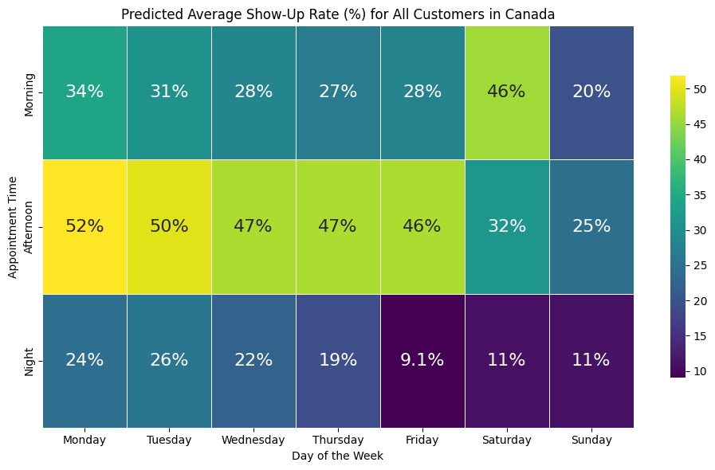

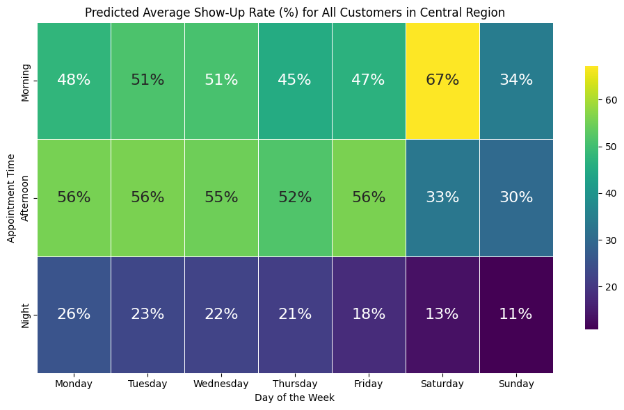

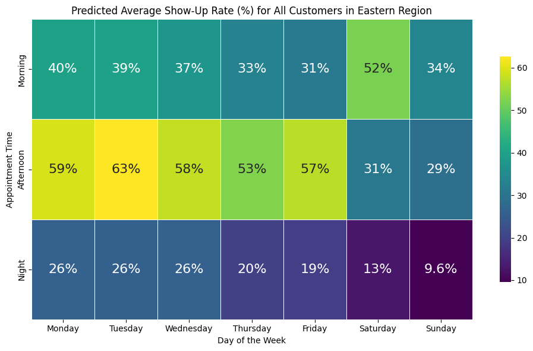

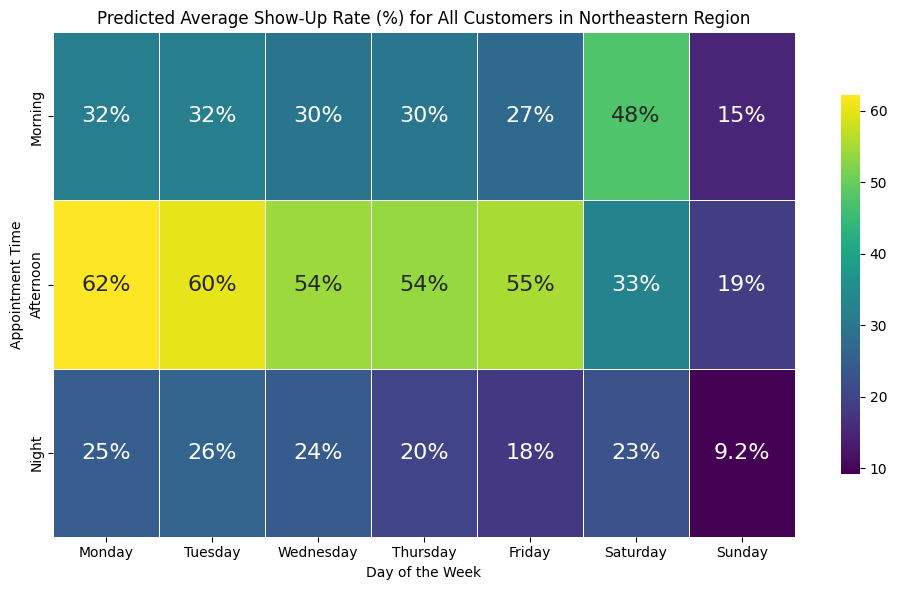

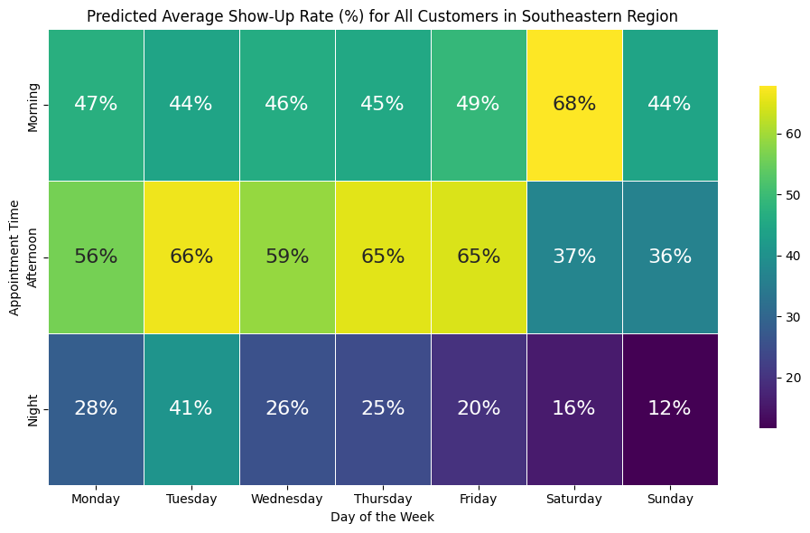

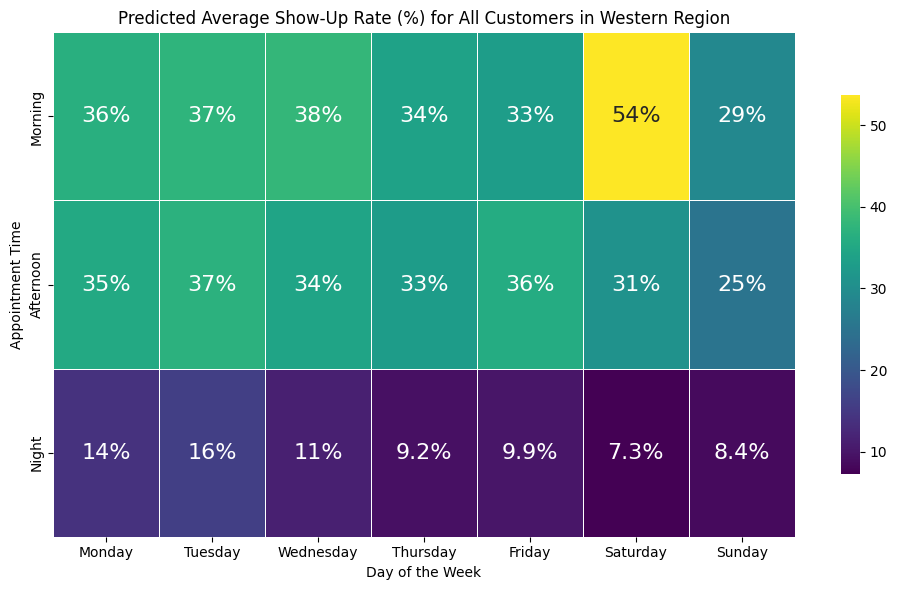

```python
regions = ['Canada', 'Central Region', 'Eastern Region', 'Northeastern Region', 'Southeastern Region', 'Western Region']
index = 0

for region in ['ISSUING_REG_DESC_CANADA REGION', 'ISSUING_REG_DESC_OPS-CENTRAL REGION',
               'ISSUING_REG_DESC_OPS-EAST REGION', 'ISSUING_REG_DESC_OPS-NORTHEAST REGION',
               'ISSUING_REG_DESC_OPS-SOUTHEAST REGION', 'ISSUING_REG_DESC_OPS-WEST REGION']:
  partial_data = all_data[all_data[region] == 1].copy()

  pivot_table = partial_data.groupby(['appointment_day', 'appointment_time'])['show_up_prob'].mean().unstack(level=-1).multiply(100).round(2)
  weekday_map = {0: 'Monday', 1: 'Tuesday', 2: 'Wednesday', 3: 'Thursday', 4: 'Friday', 5: 'Saturday', 6: 'Sunday'}
  pivot_table.index = pivot_table.index.map(weekday_map)
  pivot_table = pivot_table[['Morning', 'Afternoon', 'Night']]
  pivot_table = pivot_table.T

  plt.figure(figsize=(10, 6))
  ax = sns.heatmap(pivot_table, annot=True, cmap="viridis", linewidths=.5, cbar_kws={"shrink": 0.75}, annot_kws={"size": 16})
  plt.title('Predicted Average Show-Up Rate (%) for All Customers in ' + regions[index])
  plt.ylabel('Appointment Time')
  plt.xlabel('Day of the Week')
  for t in ax.texts: t.set_text(t.get_text() + "%")
  plt.tight_layout()
  plt.show()
  index = index + 1
```

## Comparing show-up rate across industries

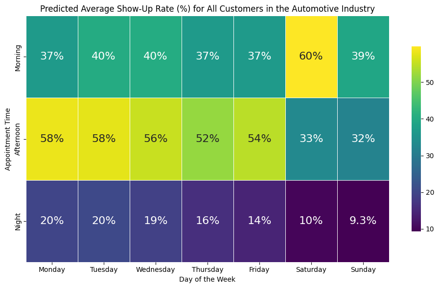

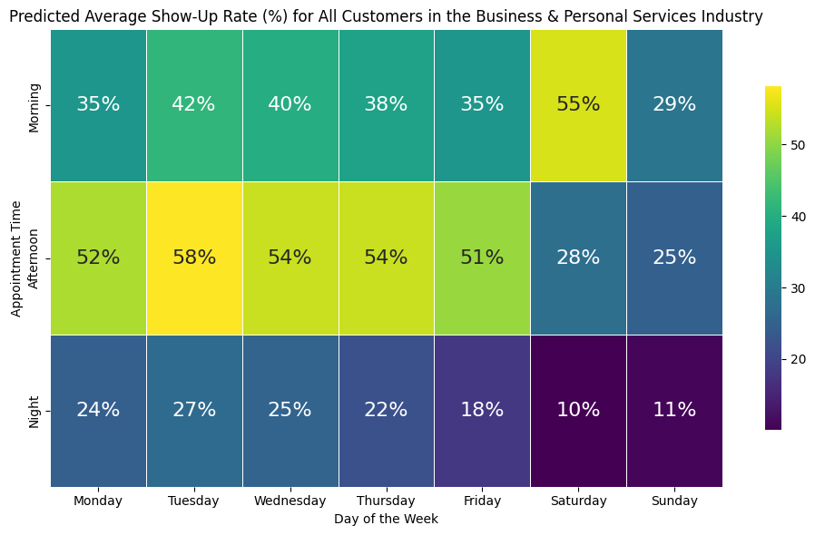

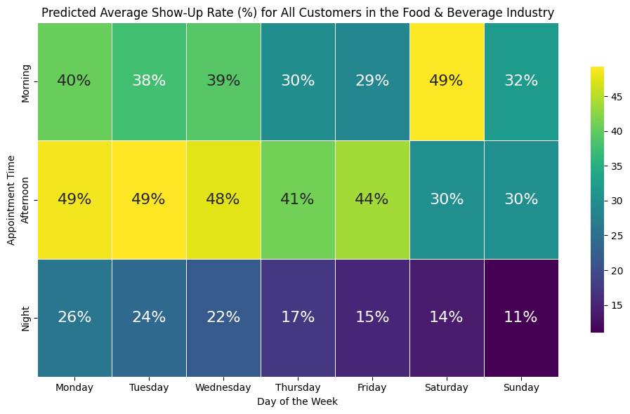

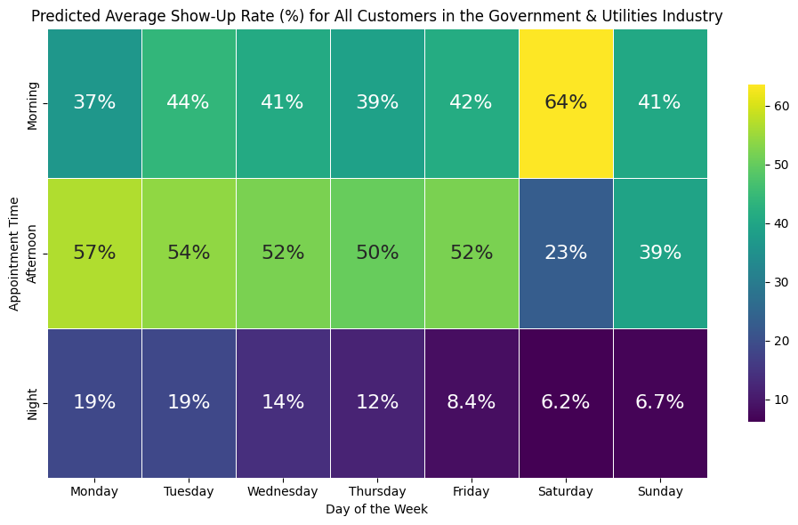

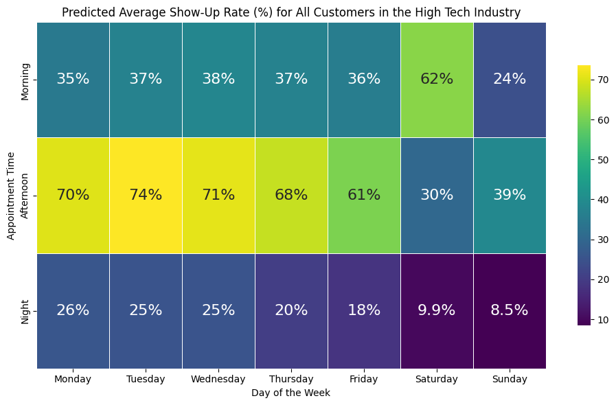

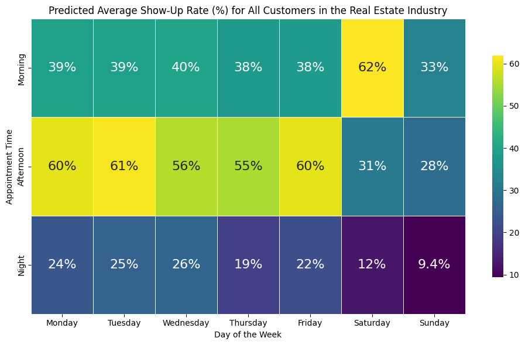

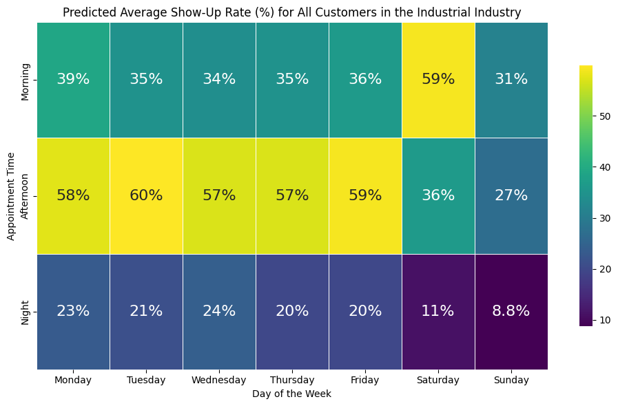

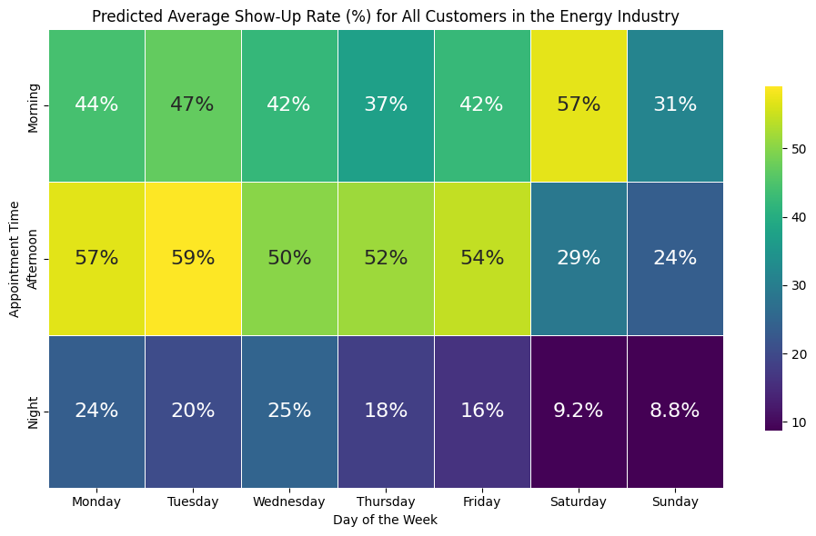

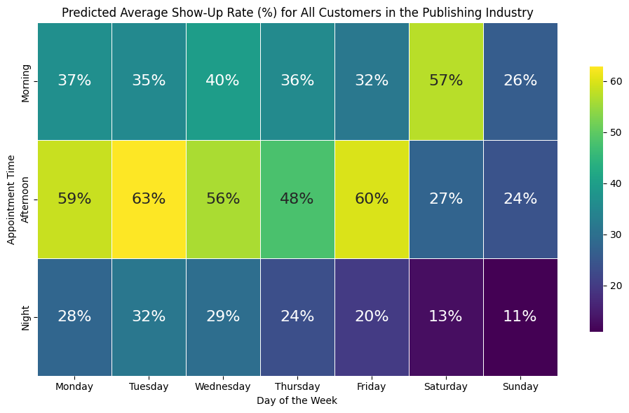

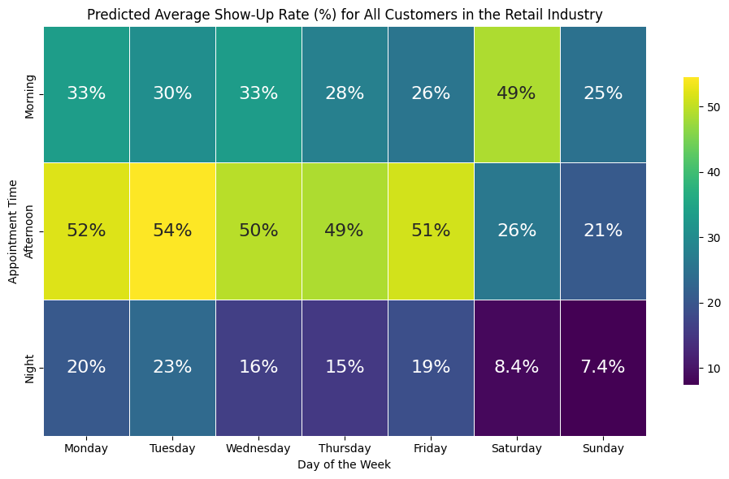

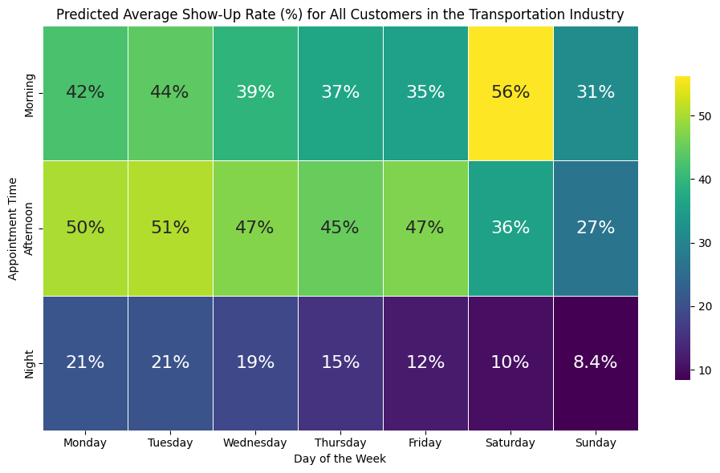

```python
industries = ['the Automotive Industry', 'the Business & Personal Services Industry',
              'the Food & Beverage Industry', 'the Government & Utilities Industry', 'the High Tech Industry',
              'the Real Estate Industry', 'the Industrial Industry', 'the Energy Industry', 'the Publishing Industry',
              'the Retail Industry', 'the Transportation Industry']
index = 0

for industry in ['INDUSTRY_GROUP_Automotive', 'INDUSTRY_GROUP_Business & Personal Services',
               'INDUSTRY_GROUP_Food & Beverage', 'INDUSTRY_GROUP_Government & Utilities',
               'INDUSTRY_GROUP_High Tech Mfg. & Distribution', 'INDUSTRY_GROUP_Housing',
               'INDUSTRY_GROUP_Industrial', 'INDUSTRY_GROUP_Oil, Chemical & Plastic Products',
               'INDUSTRY_GROUP_Paper & Publishing', 'INDUSTRY_GROUP_Retail Stores & Apparel',
               'INDUSTRY_GROUP_Transportation & Warehousing']:
  partial_data = all_data[all_data[industry] == 1].copy()

  pivot_table = partial_data.groupby(['appointment_day', 'appointment_time'])['show_up_prob'].mean().unstack(level=-1).multiply(100).round(2)
  weekday_map = {0: 'Monday', 1: 'Tuesday', 2: 'Wednesday', 3: 'Thursday', 4: 'Friday', 5: 'Saturday', 6: 'Sunday'}
  pivot_table.index = pivot_table.index.map(weekday_map)
  pivot_table = pivot_table[['Morning', 'Afternoon', 'Night']]
  pivot_table = pivot_table.T

  plt.figure(figsize=(10, 6))
  ax = sns.heatmap(pivot_table, annot=True, cmap="viridis", linewidths=.5, cbar_kws={"shrink": 0.75}, annot_kws={"size": 16})
  plt.title('Predicted Average Show-Up Rate (%) for All Customers in ' + industries[index])
  plt.ylabel('Appointment Time')
  plt.xlabel('Day of the Week')
  for t in ax.texts: t.set_text(t.get_text() + "%")
  plt.tight_layout()
  plt.show()
  index = index + 1
```

## Comparing show-up rate across appointment priority IDs

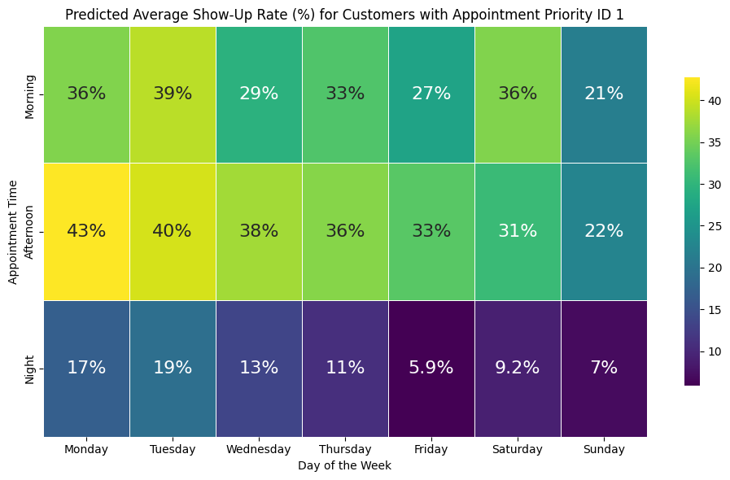

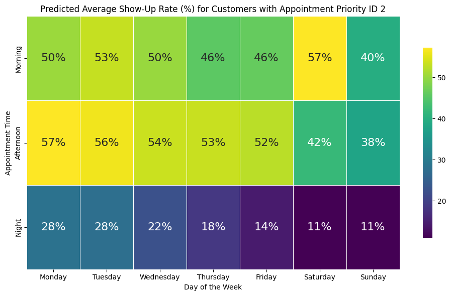

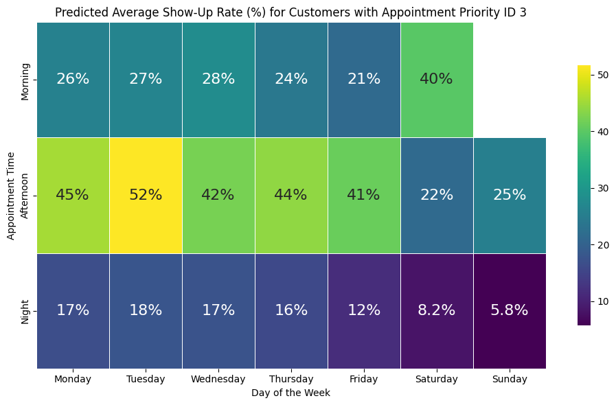

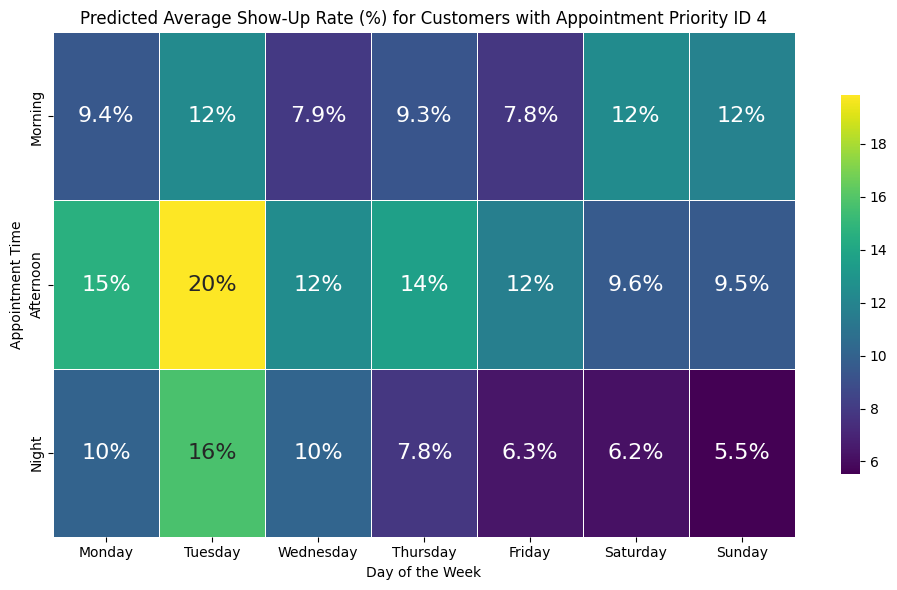

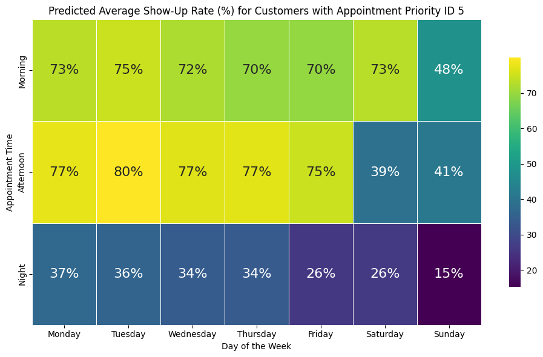

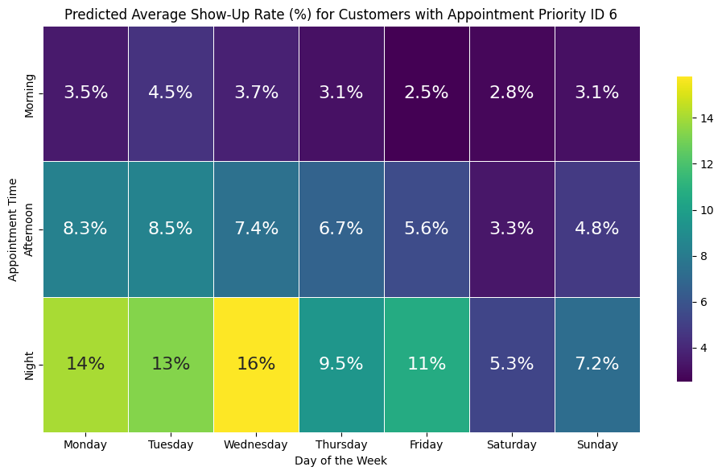

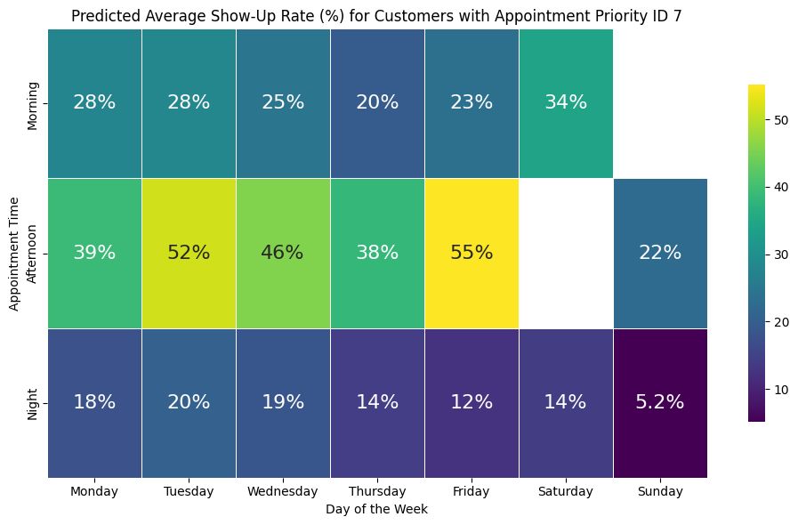

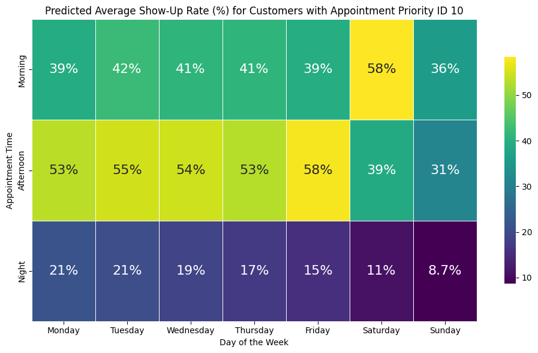

```python
ids = ['1', '2', '3', '4', '5', '6', '7', '10']
index = 0

for id in ['APPOINTMENT_PRIORITY_ID_1','APPOINTMENT_PRIORITY_ID_2', 'APPOINTMENT_PRIORITY_ID_3',
               'APPOINTMENT_PRIORITY_ID_4', 'APPOINTMENT_PRIORITY_ID_5', 'APPOINTMENT_PRIORITY_ID_6',
               'APPOINTMENT_PRIORITY_ID_7', 'APPOINTMENT_PRIORITY_ID_10']:
  partial_data = all_data[all_data[id] == 1].copy()

  pivot_table = partial_data.groupby(['appointment_day', 'appointment_time'])['show_up_prob'].mean().unstack(level=-1).multiply(100).round(2)
  weekday_map = {0: 'Monday', 1: 'Tuesday', 2: 'Wednesday', 3: 'Thursday', 4: 'Friday', 5: 'Saturday', 6: 'Sunday'}
  pivot_table.index = pivot_table.index.map(weekday_map)
  pivot_table = pivot_table[['Morning', 'Afternoon', 'Night']]
  pivot_table = pivot_table.T

  plt.figure(figsize=(10, 6))
  ax = sns.heatmap(pivot_table, annot=True, cmap="viridis", linewidths=.5, cbar_kws={"shrink": 0.75}, annot_kws={"size": 16})
  plt.title('Predicted Average Show-Up Rate (%) for Customers with Appointment Priority ID ' + ids[index])
  plt.ylabel('Appointment Time')
  plt.xlabel('Day of the Week')
  for t in ax.texts: t.set_text(t.get_text() + "%")
  plt.tight_layout()
  plt.show()
  index = index + 1
```

## Comparing show-up rate across vehicle types

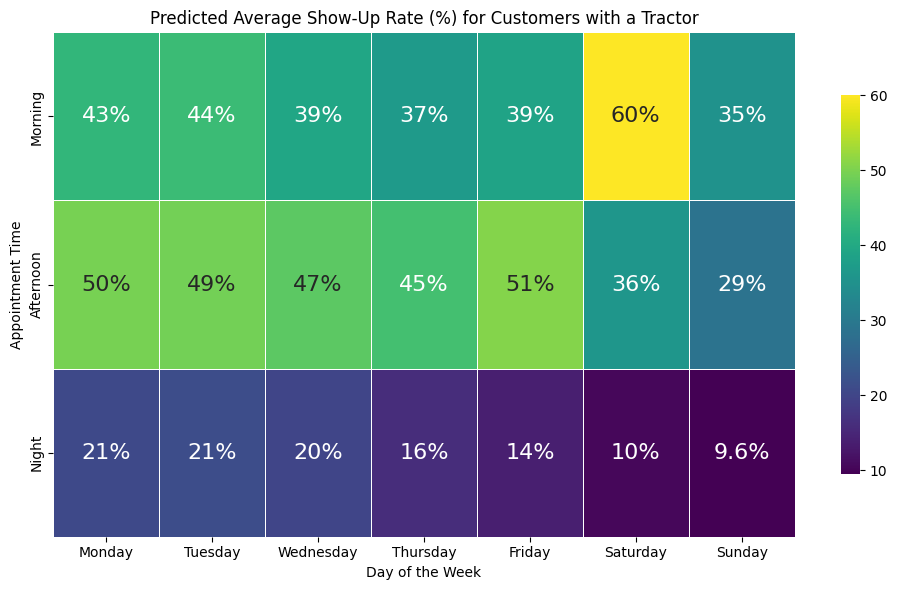

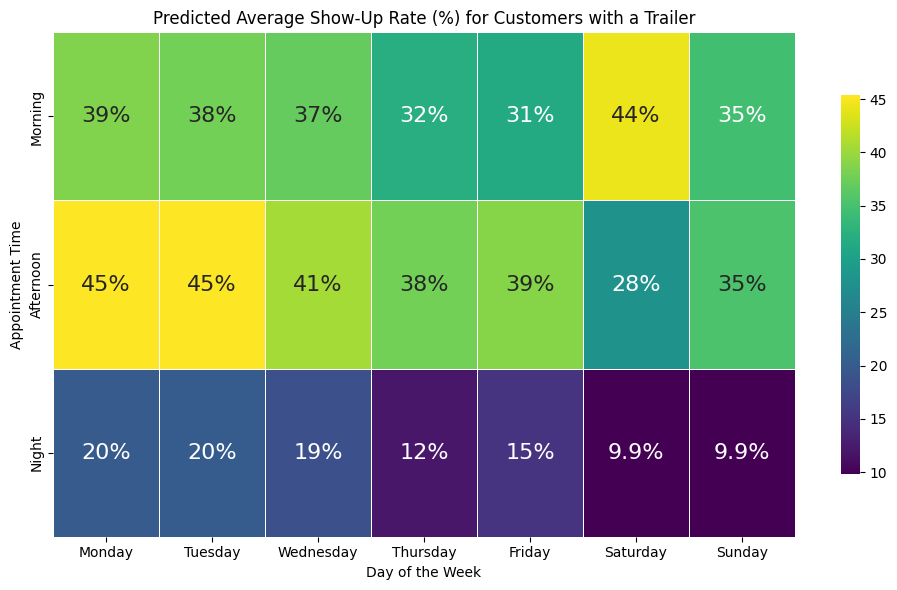

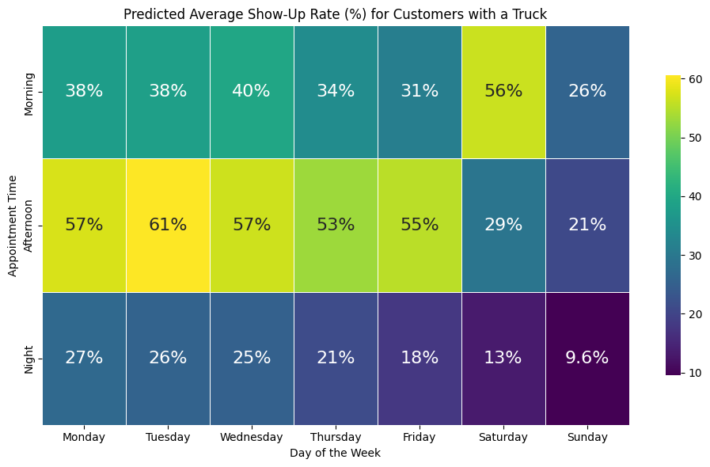

```python
vehicles = ['Tractor', 'Trailer', 'Truck']
index = 0

for vehicle in ['RIDE_VEHICLE_TYPE_DESC_TRACTOR', 'RIDE_VEHICLE_TYPE_DESC_TRAILER', 'RIDE_VEHICLE_TYPE_DESC_TRUCK']:
  partial_data = all_data[all_data[vehicle] == 1].copy()

  pivot_table = partial_data.groupby(['appointment_day', 'appointment_time'])['show_up_prob'].mean().unstack(level=-1).multiply(100).round(2)
  weekday_map = {0: 'Monday', 1: 'Tuesday', 2: 'Wednesday', 3: 'Thursday', 4: 'Friday', 5: 'Saturday', 6: 'Sunday'}
  pivot_table.index = pivot_table.index.map(weekday_map)
  pivot_table = pivot_table[['Morning', 'Afternoon', 'Night']]
  pivot_table = pivot_table.T

  plt.figure(figsize=(10, 6))
  ax = sns.heatmap(pivot_table, annot=True, cmap="viridis", linewidths=.5, cbar_kws={"shrink": 0.75}, annot_kws={"size": 16})
  plt.title('Predicted Average Show-Up Rate (%) for Customers with a ' + vehicles[index])
  plt.ylabel('Appointment Time')
  plt.xlabel('Day of the Week')
  for t in ax.texts: t.set_text(t.get_text() + "%")
  plt.tight_layout()
  plt.show()
  index = index + 1
```